# Self-reported expressibility predicts communicative success: Open dataset, validation, and simulation

Descriptive statistics

Aleksandra Ćwiek

05 August, 2025

# 1 Introduction

This is the preparation and descriptive analysis of expressibility vs. guessability, preregistered at [AsPredicted](https://aspredicted.org/kmry-vx5s.pdf).

# 2 Data preparation

## 2.1 Source setup

```r
########## folders ##########
setwd(dirname(rstudioapi::getActiveDocumentContext()$path))

parentfolder <- dirname(getwd())

rawdata       <- paste0(parentfolder, '/rawdata/')
dataset       <- paste0(parentfolder, '/dataset/')
models        <- paste0(parentfolder, '/models/')
plots         <- paste0(parentfolder, '/plots/')
scripts       <- paste0(parentfolder, '/scripts/')

########## source file ##########

#source(paste0(scripts, "adjectives-preparation.R"))

#################### packages ####################
# Data Manipulation
library(tibble)
library(stringr)
library(tidyverse) # includes readr, tidyr, dplyr, ggplot2
packageVersion("tidyverse")
```

```
## [1] '2.0.0'
```

```r
library(data.table)
library(readxl)

# Plotting
library(ggforce)
library(ggpubr)
library(gridExtra)
library(corrplot)
library(ggdist)
library(ggbeeswarm)

library(BayesFactor)

# use all available cores for parallel computing
options(mc.cores = parallel::detectCores())

colorBlindBlack8  <- c("#000000", "#E69F00", "#56B4E9", "#009E73",
                       "#F0E442", "#0072B2", "#D55E00", "#CC79A7")
```

## 2.2 Load in data frames

```r
# Load data frame
df <- read_csv(paste0(dataset, "similarity_df_final.csv"))

# Load concept list
concepts <- read_excel(paste0(dataset, "conceptlist_info.xlsx"))

# Load expressibility German
expr_german <- read_csv(paste0(dataset, "expressibility_german.csv"))

# Load expressibility Dutch
expr_dutch <- read_csv(paste0(dataset, "expressibility_dutch.csv"))
```

## 2.3 Cleaning

```r
df <- df %>%
  mutate(
    modality = case_when(
      modality == "combinatie" ~ "combined",
      modality == "gebaren" ~ "gesture",
      modality == "geluiden" ~ "vocal",
      TRUE ~ modality
    )
  ) %>%
  rename(participant_dyad = participant) %>%
  rename(participant_ID = pcnID) %>%
  rename(concept = English) %>%
  #select(-`Unnamed: 0`) %>%  # Remove the first column
  rename(stimulus = word)

# Reorder the columns in the specified order
df <- df %>%
  select(trial_order, trial_type,
         dyad, participant_dyad, participant_ID, exp_part, modality,
         expressibility_dutch, concept, correction,
         guess_binary, cosine_similarity, stimulus, answer,
         SemanticSubcat, sessionID)

# Only keep target trials
df <- df %>%
  filter(trial_type == "target")%>%
  select(-`trial_type`) # Remove trial_type columns
```

## 2.4 Exclude data points

```r
# exclude here (make to NA)
```

Adapt this code below to calculate NAs.

# 3 Descriptive statistics

How many dyads?

```r
length(unique(df$dyad))
```

```
## [1] 71
```

One dyad withdrew the consent, one dyad data still to be solved.

How many participants?

```r
length(unique(df$participant_ID))
```

```
## [1] 142
```

How many concepts?

```r
length(unique(df$concept))
```

```
## [1] 84
```

```r
length(unique(df$stimulus))
```

```
## [1] 84
```

How many productions in total?

```r
nrow(df)
```

```
## [1] 8989
```

How many productions are there per modality?

```r
df %>%
  group_by(modality) %>%
  summarise(frequency = n()) %>%
  arrange(desc(frequency)) %>%
  print(n = 100)
```

```
## # A tibble: 3 × 2
##   modality frequency
##   <chr>        <int>
## 1 vocal         3401
## 2 gesture       2799
## 3 combined      2789
```

How many productions are there per experiment part?

```r
df %>%
  group_by(exp_part) %>%
  summarise(frequency = n()) %>%
  arrange(desc(frequency)) %>%
  print(n = 100)
```

```
## # A tibble: 2 × 2
##   exp_part frequency
##      <dbl>     <int>
## 1        2      6021
## 2        1      2968
```

How many productions are there per modality within experiment part?

```r
df %>%
  group_by(exp_part, modality) %>%
  summarise(frequency = n(), .groups = "drop") %>%  # Calculate frequency for each concept and modality
  pivot_wider(names_from = modality, values_from = frequency, names_prefix = "modality_") %>%
  #arrange(desc(modality_combined), desc(modality_gesture), desc(modality_vocal)) %>%  # Sort by modality frequencies
  print(n = 100)
```

```
## # A tibble: 2 × 4
##   exp_part modality_combined modality_gesture modality_vocal
##      <dbl>             <int>            <int>          <int>
## 1        1               994              980            994
## 2        2              1795             1819           2407
```

How many productions are there per concept?

```r
df %>%
  group_by(concept) %>%
  summarise(frequency = n()) %>%
  arrange(desc(frequency)) %>%
  print(n = 100)
```

```
## # A tibble: 84 × 2
##    concept    frequency
##    <chr>          <int>
##  1 maybe            151
##  2 not              141
##  3 bitter           138
##  4 squeak           137
##  5 fly              135
##  6 to hunt          135
##  7 lightning        134
##  8 sharp            134
##  9 male             132
## 10 to know          131
## 11 loud             130
## 12 odor             130
```

[output cut: 72 more lines]

How many productions per concept within each modality?

```r
df %>%
  group_by(concept, modality) %>%
  summarise(frequency = n(), .groups = "drop") %>%  # Calculate frequency for each concept and modality
  pivot_wider(names_from = modality, values_from = frequency, names_prefix = "modality_") %>%
  arrange(desc(modality_combined), desc(modality_gesture), desc(modality_vocal)) %>%  # Sort by modality frequencies
  print(n = 100)
```

```
## # A tibble: 84 × 4
##    concept    modality_combined modality_gesture modality_vocal
##    <chr>                  <int>            <int>          <int>
##  1 maybe                     53               42             56
##  2 sharp                     48               47             39
##  3 squeak                    47               50             40
##  4 horn                      47               34             46
##  5 child                     45               46             37
##  6 bitter                    45               41             52
##  7 disgusted                 44               49             36
##  8 fly                       44               42             49
##  9 to hunt                   44               39             52
## 10 thunder                   44               34             44
## 11 to stand                  43               33             42
## 12 not                       42               47             52
```

[output cut: 72 more lines]

How many productions per concept within the experiment parts?

```r
df %>%
  group_by(concept, exp_part) %>%
  summarise(frequency = n(), .groups = "drop") %>%  # Calculate frequency for each exp_part
  pivot_wider(names_from = exp_part, values_from = frequency, names_prefix = "frequency_part") %>%
  arrange(desc(frequency_part1), desc(frequency_part2)) %>%
  print(n = 100)
```

```
## # A tibble: 84 × 3
##    concept    frequency_part1 frequency_part2
##    <chr>                <int>           <int>
##  1 to burn                 45              56
##  2 old                     45              51
##  3 buzz                    44              74
##  4 I                       44              61
##  5 dead                    43              50
##  6 to laugh                43              31
##  7 sweet                   42              85
##  8 snake                   42              56
##  9 to fly                  42              44
## 10 to growl                41              67
## 11 loud                    40              90
## 12 far                     40              76
```

[output cut: 72 more lines]

How many productions per concept within the experiment part and modality?

```r
counts_exp_modality <- df %>%
  group_by(concept, exp_part, modality) %>%  # Group by concept, experiment part, and modality
  summarise(frequency = n(), .groups = "drop") %>%  # Calculate the frequency for each group
  pivot_wider(names_from = c(modality, exp_part),
              values_from = frequency,
              names_sep = "_") %>%  # Create modality_part_1 and modality_part_2 column names
  arrange(concept)  # Sort by concept for readability

counts_exp_modality
```

| concept | combined_1 | gesture_1 | vocal_1 | combined_2 | gesture_2 | vocal_2 |
| --- | --- | --- | --- | --- | --- | --- |
| I | 13 | 14 | 17 | 20 | 20 | 21 |
| angry | 14 | 12 | 7 | 13 | 14 | 29 |
| big | 11 | 10 | 14 | 22 | 25 | 26 |
| bird | 13 | 12 | 13 | 15 | 18 | 23 |
| bitter | 12 | 13 | 10 | 33 | 28 | 42 |
| buzz | 19 | 11 | 14 | 12 | 39 | 23 |
| cat | 11 | 9 | 15 | 12 | 23 | 9 |
| child | 8 | 7 | 14 | 37 | 39 | 23 |
| cold | 10 | 13 | 12 | 14 | 10 | 14 |
| dead | 13 | 15 | 15 | 18 | 9 | 23 |

[output cut: 74 more lines]

```r
write.csv(counts_exp_modality, paste0(dataset, "counts_exp_modality.csv"), row.names = FALSE)
```

Plot productions per concept within each modality and experiment part.

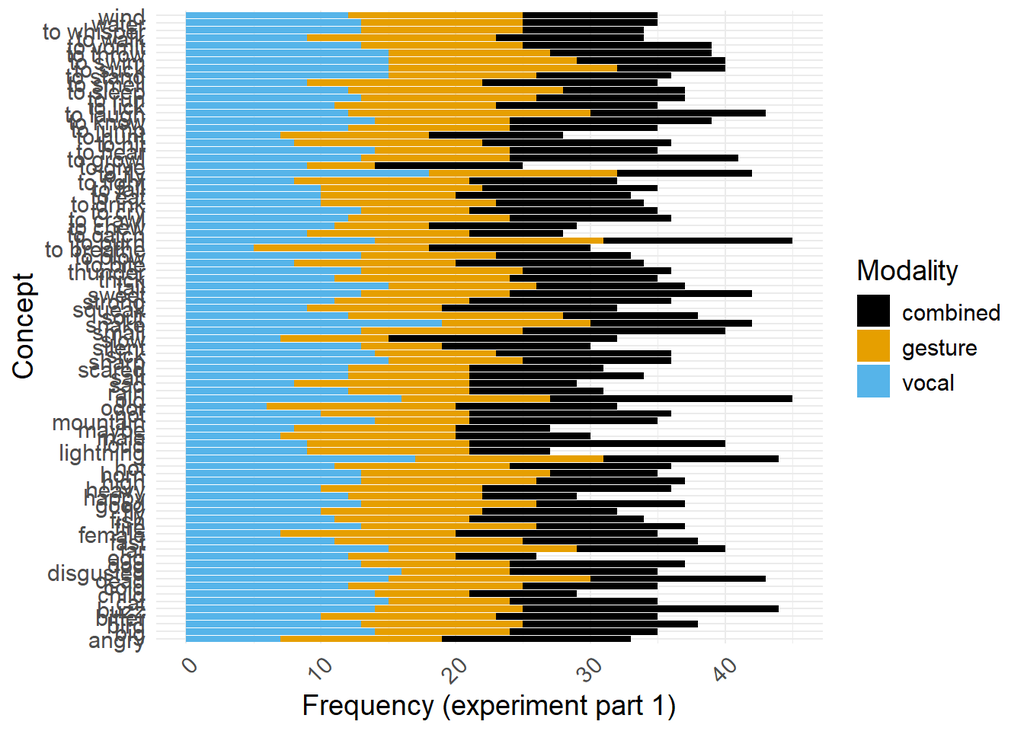

```r
# For experiment part 1
df %>%
  filter(exp_part == 1) %>%  # Filter for experiment part 1
  group_by(concept, modality) %>%
  summarise(frequency = n(), .groups = "drop") %>%  # Calculate frequency for each concept and modality
  ggplot(aes(x = concept, y = frequency, fill = modality)) +  # Set up the plot
  geom_bar(stat = "identity", position = "stack") +  # Use stacked bars to show counts
  scale_fill_manual(values = colorBlindBlack8[1:3]) +  # Use first 3 colors from colorBlindBlack8 for modalities
  labs(
    x = "Concept",
    y = "Frequency (experiment part 1)",
    fill = "Modality"
  ) +
  theme_minimal() +
  theme(
    axis.text.x = element_text(angle = 45, hjust = 1),  # Rotate x-axis labels for readability
    text = element_text(size = 14)
  ) +
  coord_flip()  # Flip coordinates to make the plot more readable
```

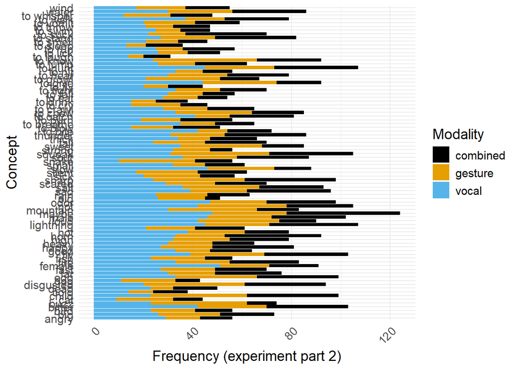

```r
ggsave(paste0(plots, "count_across_modalities_part1.png"), plot = last_plot(), width = 8, height = 10, dpi = 300)

# For experiment part 2
df %>%
  filter(exp_part == 2) %>%  # Filter for experiment part 2
  group_by(concept, modality) %>%
  summarise(frequency = n(), .groups = "drop") %>%  # Calculate frequency for each concept and modality
  ggplot(aes(x = concept, y = frequency, fill = modality)) +  # Set up the plot
  geom_bar(stat = "identity", position = "stack") +  # Use stacked bars to show counts
  scale_fill_manual(values = colorBlindBlack8[1:3]) +  # Use first 3 colors from colorBlindBlack8 for modalities
  labs(
    x = "Concept",
    y = "Frequency (experiment part 2)",
    fill = "Modality"
  ) +
  theme_minimal() +
  theme(
    axis.text.x = element_text(angle = 45, hjust = 1),  # Rotate x-axis labels for readability
    text = element_text(size = 14)
  ) +
  coord_flip()  # Flip coordinates to make the plot more readable
```

```r
ggsave(paste0(plots, "count_across_modalities_part2.png"), plot = last_plot(), width = 8, height = 10, dpi = 300)
```

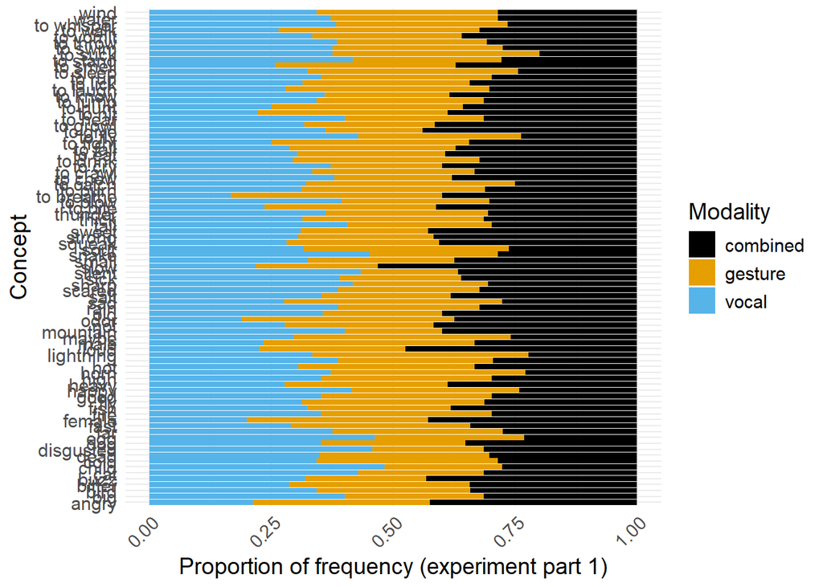

```r
# For experiment part 1
ggplot(df %>%
         filter(exp_part == 1) %>%
         group_by(concept, modality) %>%
         summarise(frequency = n(), .groups = "drop") %>%
         group_by(concept) %>%
         mutate(total = sum(frequency), proportion = frequency / total) %>%
         ungroup(), aes(x = concept, y = proportion, fill = modality)) +
  geom_bar(stat = "identity") +  # Create a stacked bar plot
  scale_fill_manual(values = colorBlindBlack8[1:3]) +  # Use the first 3 colors from colorBlindBlack8
  labs(
    x = "Concept",
    y = "Proportion of frequency (experiment part 1)",
    fill = "Modality"
  ) +
  theme_minimal() +
  theme(
    axis.text.x = element_text(angle = 45, hjust = 1),  # Rotate x-axis labels for better readability
    text = element_text(size = 14)
  ) +
  coord_flip()  # Flip coordinates for better visibility of concept names
```

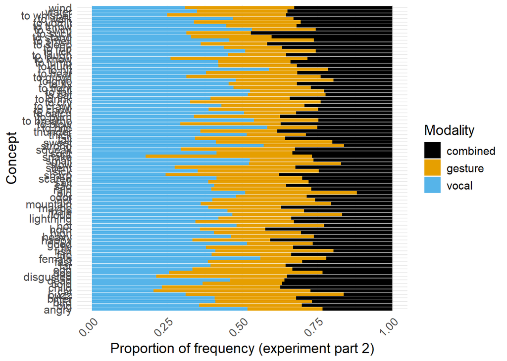

```r
ggsave(paste0(plots, "proportion_across_modalities_part1.png"), plot = last_plot(), width = 8, height = 10, dpi = 300)

# For experimentpart 2
ggplot(df %>%
         filter(exp_part == 2) %>%
         group_by(concept, modality) %>%
         summarise(frequency = n(), .groups = "drop") %>%
         group_by(concept) %>%
         mutate(total = sum(frequency), proportion = frequency / total) %>%
         ungroup(), aes(x = concept, y = proportion, fill = modality)) +
  geom_bar(stat = "identity") +  # Create a stacked bar plot
  scale_fill_manual(values = colorBlindBlack8[1:3]) +  # Use the first 3 colors from colorBlindBlack8
  labs(
    x = "Concept",
    y = "Proportion of frequency (experiment part 2)",
    fill = "Modality"
  ) +
  theme_minimal() +
  theme(
    axis.text.x = element_text(angle = 45, hjust = 1),  # Rotate x-axis labels for better readability
    text = element_text(size = 14)
  ) +
  coord_flip()  # Flip coordinates for better visibility of concept names
```

```r
ggsave(paste0(plots, "proportion_across_modalities_part2.png"), plot = last_plot(), width = 8, height = 10, dpi = 300)
```

What is the performance of each dyad? We only look at binary guessing.

```r
df %>%
  group_by(dyad) %>%
  summarise(
    total_trials = n(),  # Total number of rows per dyad
    total_guesses = sum(guess_binary == 1),  # Number of guesses where guess_binary == 1
    perf_dyad = (total_guesses / total_trials) * 100  # Percentage of correct guesses
  ) %>%
  arrange(desc(perf_dyad)) %>%  # Optional: sort by performance
  print(n = 100)
```

```
## # A tibble: 71 × 4
##     dyad total_trials total_guesses perf_dyad
##    <dbl>        <int>         <int>     <dbl>
##  1    63          108            51      47.2
##  2     3          116            48      41.4
##  3    34          117            48      41.0
##  4    51          120            48      40
##  5    42          121            48      39.7
##  6    67          123            48      39.0
##  7    64          126            48      38.1
##  8    19          122            46      37.7
##  9    54          125            47      37.6
## 10     7          120            45      37.5
## 11    65          118            44      37.3
## 12    18          126            46      36.5
```

[output cut: 59 more lines]

What is the performance of each participant within the dyad? We only look at binary guessing.

```r
df %>%
  group_by(dyad, participant_dyad) %>%
  summarise(
    total_trials = n(),  # Total number of rows per dyad
    total_guesses = sum(guess_binary == 1),  # Number of guesses where guess_binary == 1
    perf_participant = (total_guesses / total_trials) * 100  # Percentage of correct guesses
  ) %>%
  arrange(desc(perf_participant)) %>%  # Optional: sort by performance
  print(n = 150)
```

```
## # A tibble: 142 × 5
## # Groups:   dyad [71]
##      dyad participant_dyad total_trials total_guesses perf_participant
##     <dbl>            <dbl>        <int>         <int>            <dbl>
##   1    63                0           48            29             60.4
##   2    54                0           57            28             49.1
##   3     5                1           58            27             46.6
##   4    34                0           58            27             46.6
##   5    49                0           53            24             45.3
##   6    42                0           59            26             44.1
##   7    57                0           57            25             43.9
##   8     3                1           55            24             43.6
##   9    65                1           55            24             43.6
##  10    52                0           60            26             43.3
##  11    64                1           60            26             43.3
```

[output cut: 131 more lines]

### 3.0.1 Hypothesis 1: Expressibility vs. guessability

*The higher the expressibility rating of the concept for the modality in which the concept is produced, the higher the guessability will be.*

Expressibility and binary guessability?

```r
df %>%
  group_by(guess_binary) %>%
  summarise(
    mean_expressibility = mean(expressibility_dutch, na.rm = TRUE),
    sd_expressibility = sd(expressibility_dutch, na.rm = TRUE),
    min_expressibility = min(expressibility_dutch, na.rm = TRUE),
    max_expressibility = max(expressibility_dutch, na.rm = TRUE),
    median_expressibility = median(expressibility_dutch, na.rm = TRUE),
    n = n()
  )
```

| guess_binary | mean_expressibility | sd_expressibility | min_expressibility | max_expressibility | median_expressibility | n |
| --- | --- | --- | --- | --- | --- | --- |
| 0 | 0.5381214 | 0.1758246 | 0.1532559 | 0.8742039 | 0.5612810 | 6061 |
| 1 | 0.7126856 | 0.1234743 | 0.2467454 | 0.8742039 | 0.7476035 | 2928 |

Let’s visualize it.

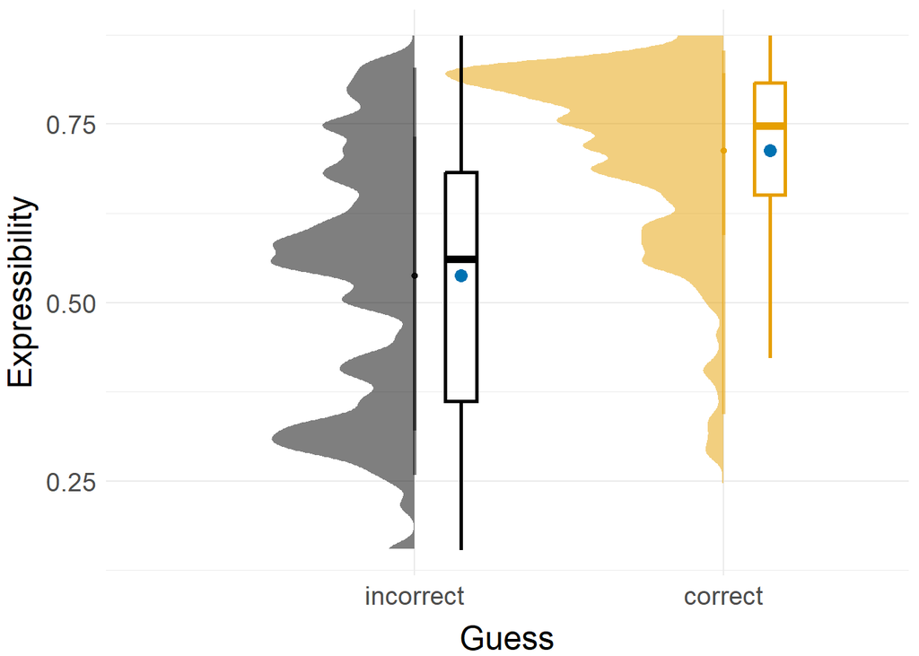

```r
ggplot(df, aes(x = expressibility_dutch, y = factor(guess_binary), fill = factor(guess_binary), color = factor(guess_binary))) +
  # Adding the slabinterval using stat_halfeye
  ggdist::stat_halfeye(
    aes(fill = factor(guess_binary), linewidth = 2),
    side = "left",  # Slabinterval on the left side
    #slab_color = NA,  # Remove outline for the slab
    interval_size = 1.2,  # Adjust interval thickness
    point_interval = mean_qi,  # Add mean and credible interval
    alpha = 0.5,
    size = 5
    #color = NA
  ) +
  # Adding geom_boxplot for the boxplot representation
  geom_boxplot(
    fill = "white",
    width = 0.10,
    lwd = 1,
    outlier.shape = NA,
    alpha = 0.5,
    position = position_nudge(y = 0.15)  # Slightly move the boxplot up to avoid overlap
  ) +
  # Adding stat_summary for the median point
  stat_summary(
    fun = mean,
    geom = "point",
    color = colorBlindBlack8[6],
    size = 3,
    position = position_nudge(y = 0.15)
  ) +
  # Customizing the colors
  scale_fill_manual(values = c("0" = colorBlindBlack8[1], "1" = colorBlindBlack8[2])) +
  scale_color_manual(values = c("0" = colorBlindBlack8[1], "1" = colorBlindBlack8[2])) +
  scale_y_discrete(labels = c("incorrect", "correct")) +  # Change x-axis labels
  coord_flip() +  # Flip the axes to match the orientation
  theme_minimal() +
  theme(
    legend.position = "none",  # Remove legend for simplicity
    plot.title = element_text(hjust = 0.5),  # Center-align the title
    axis.title.x = element_text(vjust = -0.5),  # Adjust x-axis label position
    axis.title.y = element_text(vjust = 1.5),   # Adjust y-axis label position
    text = element_text(size = 18)  # Increase font size for better readability
  ) +
  labs(
    y = "Guess",
    x = "Expressibility",
    fill = "Guess"
  )
```

```r
ggsave(paste0(plots, "H1_expressibility_guessBinary.png"), plot = last_plot(), width = 6, height = 5, dpi = 300)
```

Expressibility and cosine similarity?

```r
# Calculate correlation coefficient
cor(df$expressibility_dutch, df$cosine_similarity, use = "complete.obs")
```

```
## [1] 0.5196186
```

```r
correlationBF(df$expressibility_dutch, df$cosine_similarity)
```

```
## Ignored 7 rows containing missing observations.
```

```
## Bayes factor analysis
## --------------
## [1] Alt., r=0.333 : NA ±0%
##
## Against denominator:
##   Null, rho = 0
## ---
## Bayes factor type: BFcorrelation, Jeffreys-beta*
```

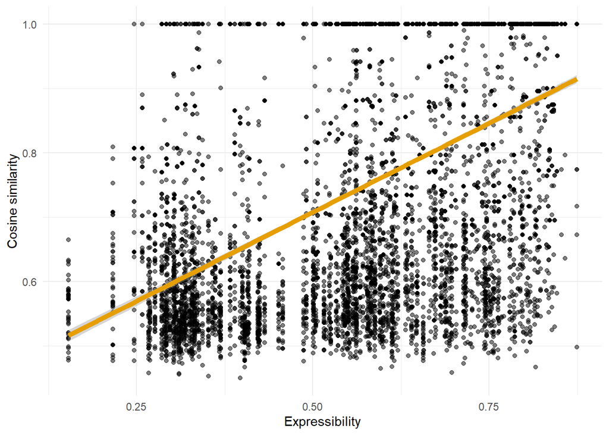

```r
# Scatter plot with correlation coefficient in the title
ggplot(df, aes(x = expressibility_dutch, y = cosine_similarity)) +
  geom_point(color = colorBlindBlack8[1], alpha = 0.5) +  # Set alpha for points
  geom_smooth(method = "lm", se = TRUE, color = colorBlindBlack8[2], size = 2) +  # Set thickness of lm line and add error bars (se = TRUE)
  scale_color_manual(
    values = colorBlindBlack8[2]
  ) +  # Rename cosine_similarity in the legend
  labs(
    x = "Expressibility",
    y = "Cosine similarity"
  ) +
  theme_minimal()
```

To better visualize the relationship let us calculate the average `cosine_similarity` for each unique `expressibility_dutch` value and create a plot where:

- **Averaged points** are plotted on the graph.
- The size of the dots represents the number of original observations contributing to each averaged point.
- This will make it easier to see whether the relationship between `expressibility_dutch` and `cosine_similarity` is linear on average.

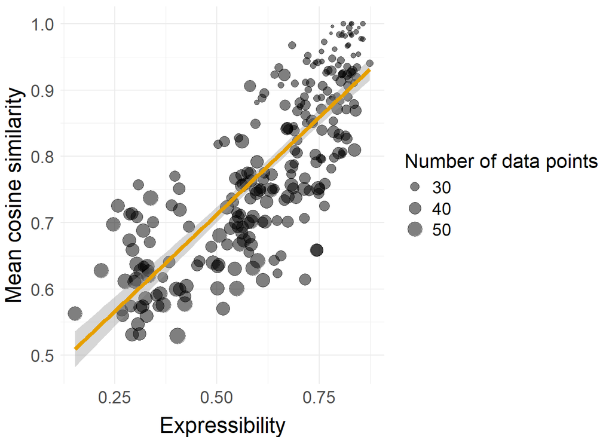

```r
df %>%
  group_by(expressibility_dutch) %>%
  summarise(
    mean_cosine_similarity = mean(cosine_similarity, na.rm = TRUE),  # Mean cosine similarity
    n = n()  # Count of data points for each unique x value
  ) %>%
  ggplot(aes(x = expressibility_dutch, y = mean_cosine_similarity, size = n)) +
  geom_point(color = colorBlindBlack8[1], alpha = 0.5) +  # Scatterplot with size mapped to n
  geom_smooth(method = "lm", se = TRUE, color = colorBlindBlack8[2], size = 1.5) +  # Linear regression line with error bars
  theme_minimal() +
  theme(
    plot.title = element_text(hjust = 0.5, size = 20),  # Center-align and size of plot title
    axis.title.x = element_text(vjust = -0.5, size = 18),  # Adjust x-axis label position and size
    axis.title.y = element_text(vjust = 1.5, size = 18),   # Adjust y-axis label position and size
    axis.text.x = element_text(size = 14),  # Set size of x-axis text
    axis.text.y = element_text(size = 14),  # Set size of y-axis text
    legend.title = element_text(size = 16),  # Set size of legend title
    legend.text = element_text(size = 14),  # Set size of legend text
    text = element_text(size = 18)  # Increase general font size for better readability
  ) +
  labs(
    x = "Expressibility",
    y = "Mean cosine similarity",
    size = "Number of data points"
  )
```

```r
ggsave(paste0(plots, "H1_expressibility_guessSimilarity.png"), plot = last_plot(), width = 8, height = 5, dpi = 300)
```

### 3.0.2 Hypothesis 2: Expressibility vs. repetitions

*The higher the expressibility rating of the concept for the modality in which the concept is produced, the fewer repetitions there will be.*

Calculate correlation between expressibility and correction

```r
df_part2 <- df %>%
  filter(exp_part == 2)

# Calculate correlation coefficient
cor(df_part2$expressibility_dutch, df_part2$correction, use = "complete.obs")
```

```
## [1] -0.2556249
```

```r
correlationBF(df_part2$expressibility_dutch, df_part2$correction)
```

```
## Bayes factor analysis
## --------------
## [1] Alt., r=0.333 : 5.207852e+86 ±0%
##
## Against denominator:
##   Null, rho = 0
## ---
## Bayes factor type: BFcorrelation, Jeffreys-beta*
```

- The **Pearson correlation** of **-0.256** indicates a **weak negative relationship** between **expressibility** and **correction**, meaning that higher expressibility ratings tend to be associated with fewer repetitions.
- The **Bayesian analysis** strongly supports this observation, providing **strong evidence for a non-zero correlation** between the two variables, which reinforces the weak correlation observed through Pearson’s method.
- Even though the correlation is weak, the Bayesian evidence suggests a meaningful relationship between expressibility and the number of repetitions, meaning that we can expect some relationship between these two variables.

The **weak negative correlation** suggests that more **expressible concepts** may be corrected fewer times, although the relationship isn’t very strong.

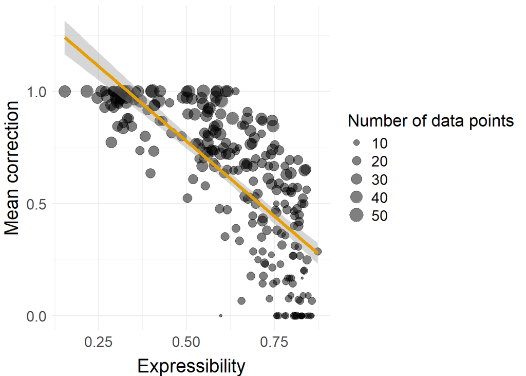

```r
df %>%
  filter(exp_part == 2) %>%
  group_by(expressibility_dutch) %>%
  summarise(
    mean_correction = mean(correction, na.rm = TRUE),  # Mean cosine similarity
    n = n()  # Count of data points for each unique x value
  ) %>%
  ggplot(aes(x = expressibility_dutch, y = mean_correction, size = n)) +
  geom_point(color = colorBlindBlack8[1], alpha = 0.5) +  # Scatterplot with size mapped to n
  geom_smooth(method = "lm", se = TRUE, color = colorBlindBlack8[2], size = 1.5) +  # Linear regression line with error bars
  theme_minimal() +
  theme(
    plot.title = element_text(hjust = 0.5, size = 20),  # Center-align and size of plot title
    axis.title.x = element_text(vjust = -0.5, size = 18),  # Adjust x-axis label position and size
    axis.title.y = element_text(vjust = 1.5, size = 18),   # Adjust y-axis label position and size
    axis.text.x = element_text(size = 14),  # Set size of x-axis text
    axis.text.y = element_text(size = 14),  # Set size of y-axis text
    legend.title = element_text(size = 16),  # Set size of legend title
    legend.text = element_text(size = 14),  # Set size of legend text
    text = element_text(size = 18)  # Increase general font size for better readability
  ) +
  labs(
    x = "Expressibility",
    y = "Mean correction",
    size = "Number of data points"
  )
```

```r
ggsave(paste0(plots, "H2_expressibility_correctionContinuous.png"), plot = last_plot(), width = 8, height = 5, dpi = 300)
```

What if we do not treat correction as continuous but categorical?

```r
df %>%
  filter(exp_part == 2) %>%
  group_by(correction) %>%
  summarise(
    mean_expressibility = mean(expressibility_dutch, na.rm = TRUE),  # Mean expressibility rating
    sd_expressibility = sd(expressibility_dutch, na.rm = TRUE),  # Standard deviation of expressibility
    median_expressibility = median(expressibility_dutch, na.rm = TRUE),  # Median expressibility
    n = n()  # Number of data points in each correction group
  )
```

| correction | mean_expressibility | sd_expressibility | median_expressibility | n |
| --- | --- | --- | --- | --- |
| 0 | 0.6242162 | 0.1745023 | 0.6671712 | 2982 |
| 1 | 0.5566477 | 0.1752854 | 0.5775450 | 1787 |
| 2 | 0.5107262 | 0.1683722 | 0.5459140 | 1252 |

Let’s visualize it.

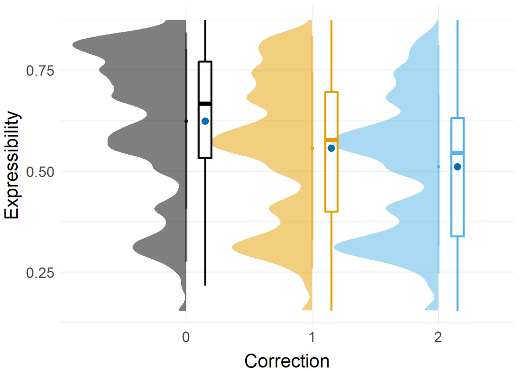

```r
df %>%
  filter(exp_part == 2) %>%
  ggplot(aes(x = expressibility_dutch, y = factor(correction), fill = factor(correction), color = factor(correction))) +
    # Adding the slabinterval using stat_halfeye
    ggdist::stat_halfeye(
      aes(fill = factor(correction), linewidth = 2),
      side = "left",  # Slabinterval on the left side
      #slab_color = NA,  # Remove outline for the slab
      interval_size = 1.2,  # Adjust interval thickness
      point_interval = mean_qi,  # Add mean and credible interval
      alpha = 0.5,
      size = 5
      #color = NA
    ) +
    # Adding geom_boxplot for the boxplot representation
    geom_boxplot(
      fill = "white",
      width = 0.10,
      lwd = 1,
      outlier.shape = NA,
      alpha = 0.5,
      position = position_nudge(y = 0.15)  # Slightly move the boxplot up to avoid overlap
    ) +
    # Adding stat_summary for the median point
    stat_summary(
      fun = mean,
      geom = "point",
      color = colorBlindBlack8[6],
      size = 3,
      position = position_nudge(y = 0.15)
    ) +
    # Customizing the colors
    scale_fill_manual(values = c("0" = colorBlindBlack8[1], "1" = colorBlindBlack8[2], "2" = colorBlindBlack8[3])) +
    scale_color_manual(values = c("0" = colorBlindBlack8[1], "1" = colorBlindBlack8[2], "2" = colorBlindBlack8[3])) +
    #scale_y_discrete(labels = c("incorrect", "correct")) +  # Change x-axis labels
    coord_flip() +  # Flip the axes to match the orientation
    theme_minimal() +
    theme(
      legend.position = "none",  # Remove legend for simplicity
      plot.title = element_text(hjust = 0.5),  # Center-align the title
      axis.title.x = element_text(vjust = -0.5),  # Adjust x-axis label position
      axis.title.y = element_text(vjust = 1.5),   # Adjust y-axis label position
      text = element_text(size = 18)  # Increase font size for better readability
    ) +
    labs(
      y = "Correction",
      x = "Expressibility",
      fill = "Correction"
    )
```

```r
ggsave(paste0(plots, "H2_expressibility_correctionBinary.png"), plot = last_plot(), width = 6, height = 5, dpi = 300)
```

Just for exploration: modality mean expressibility and repetitions.

```r
df %>%
  filter(exp_part == 2) %>%
  group_by(modality) %>%
  summarise(
    mean_expressibility = mean(expressibility_dutch, na.rm = TRUE),  # Mean expressibility rating
    sd_expressibility = sd(expressibility_dutch, na.rm = TRUE),  # Standard deviation of expressibility
    mean_correction = mean(correction, na.rm = TRUE),  # Mean correction value (interpreted continuously)
    sd_correction = sd(correction, na.rm = TRUE),  # Standard deviation of correction
    cor_expressibility_correction = cor(expressibility_dutch, correction, use = "complete.obs")  # Correlation between expressibility and correction
  )
```

| modality | mean_expressibility | sd_expressibility | mean_correction | sd_correction | cor_expressibility_correction |
| --- | --- | --- | --- | --- | --- |
| combined | 0.6773800 | 0.1192820 | 0.6111421 | 0.7535043 | -0.2527622 |
| gesture | 0.6365939 | 0.1486922 | 0.6239692 | 0.7588114 | -0.2653901 |
| vocal | 0.4660199 | 0.1754800 | 0.8554217 | 0.8128454 | -0.1642631 |

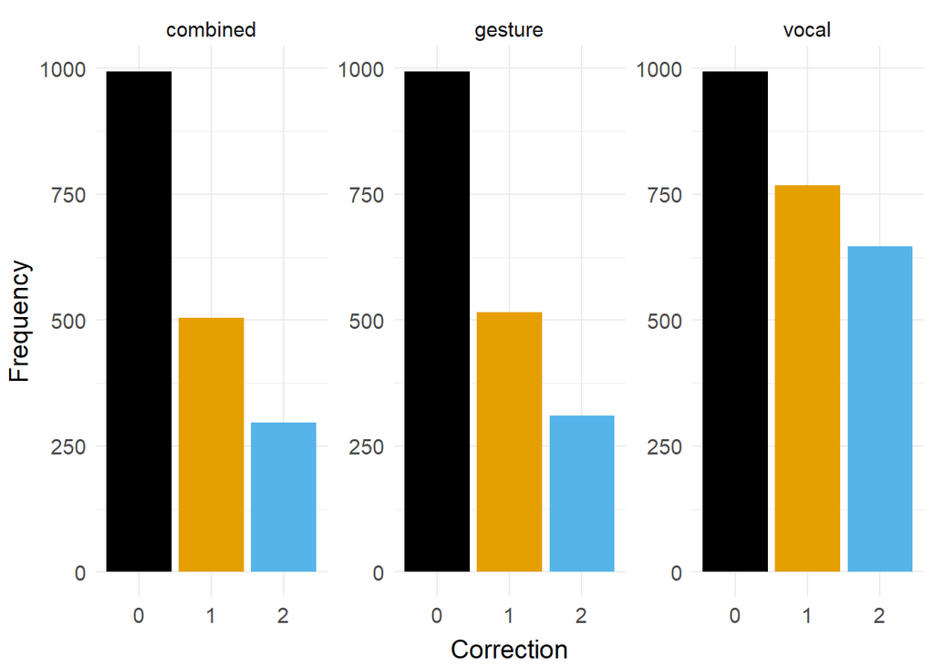

```r
df %>%
  filter(exp_part == 2) %>%
  ggplot(aes(x = factor(correction), fill = factor(correction))) +
  geom_bar(stat = "count", position = "dodge") +  # Count occurrences of each correction value
  facet_wrap(~ modality, scales = "free_y") +  # Facet by modality to show counts for each modality
  scale_fill_manual(values = c("0" = colorBlindBlack8[1], "1" = colorBlindBlack8[2], "2" = colorBlindBlack8[3])) +  # Custom colors for correction values
  labs(
    x = "Correction",
    y = "Frequency"
    #fill = "Repetition Number",
  ) +
  guides(fill = "none") +  # Remove the fill legend
  theme_minimal() +
  theme(
    text = element_text(size = 14),  # Increase text size for readability
    axis.title.x = element_text(vjust = -0.5),  # Adjust x-axis title position
    axis.title.y = element_text(vjust = 1.5)   # Adjust y-axis title position
  )
```

```r
ggsave(paste0(plots, "corrections_across_modalities.png"), plot = last_plot(), width = 6, height = 4, dpi = 300)
```

### 3.0.3 Hypothesis 3: Guessability vs. experiment part

*Guessability is higher when there is feedback between a producer and a guesser (i.e., in the second half of the experiment, where the guesser knows if they answered correctly, and the producer knows what the guesser answered).*

#### 3.0.3.1 All from part 2

Experiment parts and binary guessability

```r
df %>%
  group_by(exp_part) %>%
  summarise(
    total_trials = n(),  # Total number of rows for this experiment part
    total_guesses = sum(guess_binary == 1),  # Total successful guesses for this experiment part
    overall_performance = (total_guesses / total_trials) * 100  # Performance percentage
  ) %>%
  arrange(exp_part)  # Optional: Sort by experiment part
```

| exp_part | total_trials | total_guesses | overall_performance |
| --- | --- | --- | --- |
| 1 | 2968 | 1013 | 34.13073 |
| 2 | 6021 | 1915 | 31.80535 |

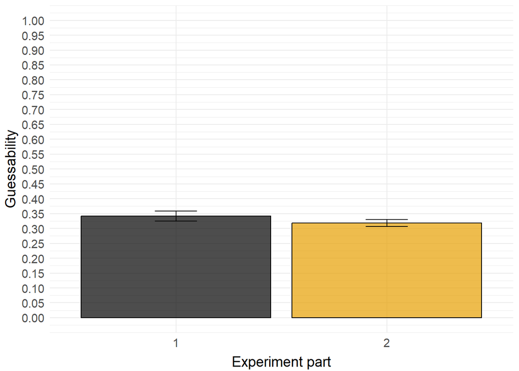

```r
ggplot(df, aes(x = factor(exp_part), y = guess_binary, fill = factor(exp_part))) +
  stat_summary(fun = "mean", geom = "bar", color = "black", alpha = 0.7) +  # Calculate mean for guess_binary (performance)
  stat_summary(fun.data = "mean_cl_normal", geom = "errorbar", width = 0.2) +  # Add error bars (95% CI)
  labs(
    x = "Experiment part",
    y = "Guessability",
  ) +
  scale_fill_manual(values = c("1" = colorBlindBlack8[1], "2" = colorBlindBlack8[2])) +
  guides(fill = "none") +  # Remove the fill legend
  scale_y_continuous(breaks = seq(0, 1, by = 0.05),
                     limits = c(0,1)) +
  theme_minimal() +
  theme(
    text = element_text(size = 14),  # Increase text size for readability
    axis.title.x = element_text(vjust = -0.5),  # Adjust x-axis title position
    axis.title.y = element_text(vjust = 1.5)   # Adjust y-axis title position
  )
```

```r
ggsave(paste0(plots, "H3_guessBinary_all.png"), plot = last_plot(), width = 6, height = 6, dpi = 300)
```

Experiment parts and cosine similarity

```r
df %>%
  group_by(exp_part) %>%
  summarise(
    avg_cosine_similarity = mean(cosine_similarity, na.rm = TRUE),  # Mean cosine similarity
    sd_cosine_similarity = sd(cosine_similarity, na.rm = TRUE),    # Standard deviation
    total_trials = n()  # Total number of trials for reference
  ) %>%
  arrange(exp_part)  # Optional: Sort by experiment part
```

| exp_part | avg_cosine_similarity | sd_cosine_similarity | total_trials |
| --- | --- | --- | --- |
| 1 | 0.7656928 | 0.1942263 | 2968 |
| 2 | 0.7578923 | 0.1906989 | 6021 |

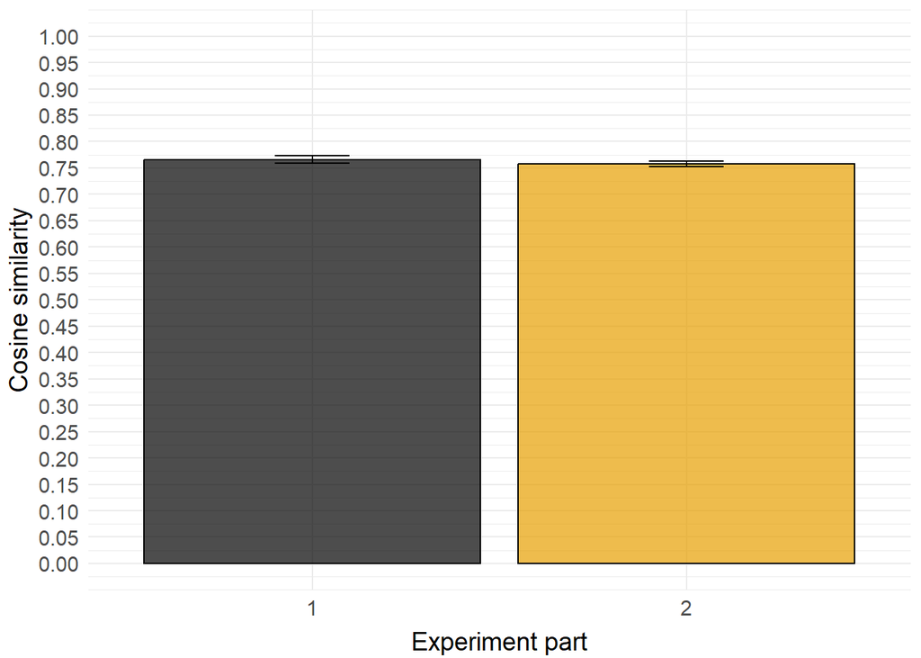

```r
ggplot(df, aes(x = factor(exp_part), y = cosine_similarity, fill = factor(exp_part))) +
  stat_summary(fun = "mean", geom = "bar", color = "black", alpha = 0.7) +
  stat_summary(fun.data = "mean_cl_normal", geom = "errorbar", width = 0.2) +  # Add error bars (95% CI)
  labs(
    x = "Experiment part",
    y = "Cosine similarity",
  ) +
  scale_fill_manual(values = c("1" = colorBlindBlack8[1], "2" = colorBlindBlack8[2])) +
  guides(fill = "none") +  # Remove the fill legend
  scale_y_continuous(breaks = seq(0, 1, by = 0.05),
                     limits = c(0,1)) +
  theme_minimal() +
  theme(
    text = element_text(size = 14),  # Increase text size for readability
    axis.title.x = element_text(vjust = -0.5),  # Adjust x-axis title position
    axis.title.y = element_text(vjust = 1.5)   # Adjust y-axis title position
  )
```

```r
ggsave(paste0(plots, "H3_guessSimilarity_all.png"), plot = last_plot(), width = 6, height = 6, dpi = 300)
```

#### 3.0.3.2 Only first from part 2

In part 1, participants only had one shot at trying. In part 2, they had up to three trials, so 2 corrections. Let us compare only the first production from the second part to the production from part 1.

Start with binary guess.

```r
df %>%
  filter(exp_part == 1 | (exp_part == 2 & correction == 0)) %>%
  group_by(exp_part) %>%
  summarise(
    total_trials = n(),
    total_guesses = sum(guess_binary == 1),
    overall_performance = (total_guesses / total_trials) * 100
  ) %>%
  arrange(exp_part)
```

| exp_part | total_trials | total_guesses | overall_performance |
| --- | --- | --- | --- |
| 1 | 2968 | 1013 | 34.13073 |
| 2 | 2982 | 1168 | 39.16834 |

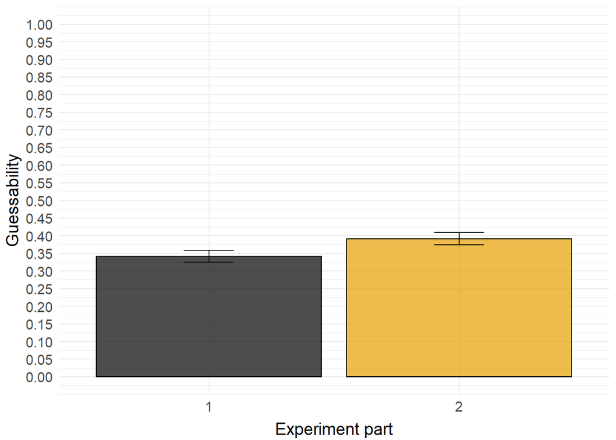

```r
df %>%
  filter(exp_part == 1 | (exp_part == 2 & correction == 0)) %>%
  ggplot(aes(x = factor(exp_part), y = guess_binary, fill = factor(exp_part))) +
    stat_summary(fun = "mean", geom = "bar", color = "black", alpha = 0.7) +  # Calculate mean for guess_binary (performance)
    stat_summary(fun.data = "mean_cl_normal", geom = "errorbar", width = 0.2) +  # Add error bars (95% CI)
    labs(
      x = "Experiment part",
      y = "Guessability",
    ) +
    scale_fill_manual(values = c("1" = colorBlindBlack8[1], "2" = colorBlindBlack8[2])) +
    guides(fill = "none") +  # Remove the fill legend
    scale_y_continuous(breaks = seq(0, 1, by = 0.05),
                       limits = c(0,1)) +
    theme_minimal() +
  theme(
    text = element_text(size = 14),  # Increase text size for readability
    axis.title.x = element_text(vjust = -0.5),  # Adjust x-axis title position
    axis.title.y = element_text(vjust = 1.5)   # Adjust y-axis title position
  )
```

```r
ggsave(paste0(plots, "H3_guessBinary_first.png"), plot = last_plot(), width = 6, height = 6, dpi = 300)
```

Now to cosine similarity.

Experiment parts and cosine similarity

```r
df %>%
  filter(exp_part == 1 | (exp_part == 2 & correction == 0)) %>%
  group_by(exp_part) %>%
  summarise(
    avg_cosine_similarity = mean(cosine_similarity, na.rm = TRUE),
    sd_cosine_similarity = sd(cosine_similarity, na.rm = TRUE),
    total_trials = n()
  ) %>%
  arrange(exp_part)
```

| exp_part | avg_cosine_similarity | sd_cosine_similarity | total_trials |
| --- | --- | --- | --- |
| 1 | 0.7656928 | 0.1942263 | 2968 |
| 2 | 0.7918418 | 0.1910976 | 2982 |

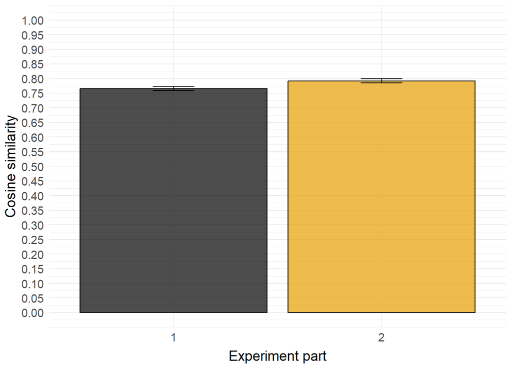

```r
df %>%
  filter(exp_part == 1 | (exp_part == 2 & correction == 0)) %>%
  ggplot(aes(x = factor(exp_part), y = cosine_similarity, fill = factor(exp_part))) +
    stat_summary(fun = "mean", geom = "bar", color = "black", alpha = 0.7) +
    stat_summary(fun.data = "mean_cl_normal", geom = "errorbar", width = 0.2) +  # Add error bars (95% CI)
    labs(
      x = "Experiment part",
      y = "Cosine similarity",
    ) +
    scale_fill_manual(values = c("1" = colorBlindBlack8[1], "2" = colorBlindBlack8[2])) +
    guides(fill = "none") +  # Remove the fill legend
    scale_y_continuous(breaks = seq(0, 1, by = 0.05),
                       limits = c(0,1)) +
    theme_minimal() +
    theme(
      text = element_text(size = 14),  # Increase text size for readability
      axis.title.x = element_text(vjust = -0.5),  # Adjust x-axis title position
      axis.title.y = element_text(vjust = 1.5)   # Adjust y-axis title position
    )
```

```r
ggsave(paste0(plots, "H3_guessSimilarity_first.png"), plot = last_plot(), width = 6, height = 6, dpi = 300)
```

Sarka’s plot

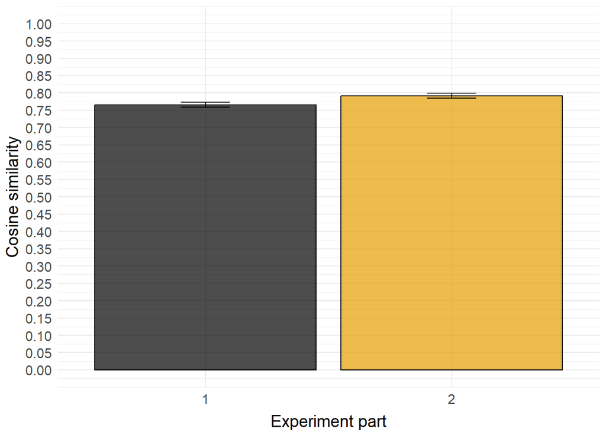

```r
# talk to Sarka next week what she meant

df %>%
  filter(exp_part == 1 | (exp_part == 2 & correction == 0)) %>%
  ggplot(aes(x = factor(exp_part), y = cosine_similarity, fill = factor(exp_part))) +
    stat_summary(fun = "mean", geom = "bar", color = "black", alpha = 0.7) +
    stat_summary(fun.data = "mean_cl_normal", geom = "errorbar", width = 0.2) +  # Add error bars (95% CI)
    labs(
      x = "Experiment part",
      y = "Cosine similarity",
    ) +
    scale_fill_manual(values = c("1" = colorBlindBlack8[1], "2" = colorBlindBlack8[2])) +
    guides(fill = "none") +  # Remove the fill legend
    scale_y_continuous(breaks = seq(0, 1, by = 0.05),
                       limits = c(0,1)) +
    theme_minimal() +
    theme(
      text = element_text(size = 14),  # Increase text size for readability
      axis.title.x = element_text(vjust = -0.5),  # Adjust x-axis title position
      axis.title.y = element_text(vjust = 1.5)   # Adjust y-axis title position
    )
```

### 3.0.4 Hypothesis 4: Guessability vs. modality

*Guessability will differ by modality; the order from highest to lowest will be: combined > gesture > vocalization.*

Modalities and binary guessability.

```r
df %>%
  group_by(modality) %>%
  summarise(
    total_trials = n(),  # Number of trials for each modality
    total_guesses = sum(guess_binary == 1),  # Number of correct guesses
    perf_modality = (total_guesses / total_trials) * 100  # Performance as percentage
  ) %>%
  arrange(desc(perf_modality))
```

| modality | total_trials | total_guesses | perf_modality |
| --- | --- | --- | --- |
| combined | 2789 | 1197 | 42.91861 |
| gesture | 2799 | 1183 | 42.26509 |
| vocal | 3401 | 548 | 16.11291 |

Visualize the binary guessability across modalities.

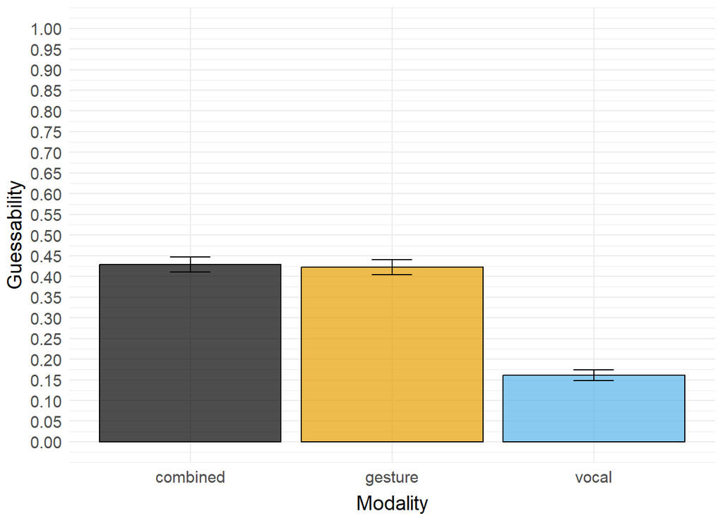

```r
ggplot(df, aes(x = modality, y = guess_binary, fill = modality)) +
  stat_summary(fun = "mean", geom = "bar", color = "black", alpha = 0.7) +  # Calculate mean for guess_binary (performance)
  stat_summary(fun.data = "mean_cl_normal", geom = "errorbar", width = 0.2) +  # Add error bars (95% CI)
  labs(
    x = "Modality",
    y = "Guessability",
  ) +
  scale_fill_manual(values = c("combined" = colorBlindBlack8[1], "gesture" = colorBlindBlack8[2], "vocal" = colorBlindBlack8[3])) +  # Customize colors
  guides(fill = "none") +  # Remove the fill legend
  scale_y_continuous(breaks = seq(0, 1, by = 0.05),
                     limits = c(0,1)) +
  theme_minimal() +
    theme(
      text = element_text(size = 14),  # Increase text size for readability
      axis.title.x = element_text(vjust = -0.5),  # Adjust x-axis title position
      axis.title.y = element_text(vjust = 1.5)   # Adjust y-axis title position
    )
```

```r
ggsave(paste0(plots, "H4_modality_guessBinary.png"), plot = last_plot(), width = 6, height = 6, dpi = 300)
```

Modalities and cosine similarity

```r
df %>%
  group_by(modality) %>%
  summarise(
    total_trials = n(),  # Number of trials for each modality
    mean_cosine_similarity = mean(cosine_similarity, na.rm = TRUE),  # Mean cosine similarity
    sd_cosine_similarity = sd(cosine_similarity, na.rm = TRUE),  # Standard deviation of cosine similarity
    perf_modality = (mean_cosine_similarity) * 100  # Performance as percentage
  ) %>%
  arrange(desc(perf_modality))
```

| modality | total_trials | mean_cosine_similarity | sd_cosine_similarity | perf_modality |
| --- | --- | --- | --- | --- |
| combined | 2789 | 0.8144216 | 0.1851224 | 81.44216 |
| gesture | 2799 | 0.8101253 | 0.1861222 | 81.01253 |
| vocal | 3401 | 0.6753463 | 0.1704999 | 67.53463 |

Visualize the cosine similarity across modalities

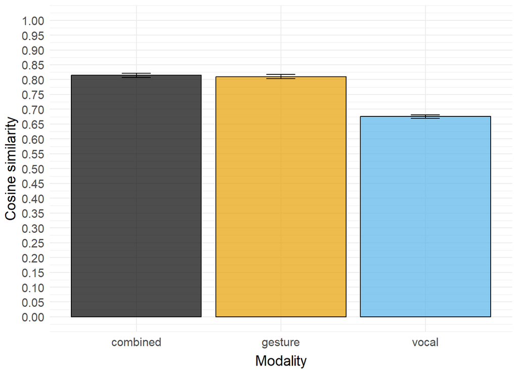

```r
ggplot(df, aes(x = modality, y = cosine_similarity, fill = modality)) +
  stat_summary(fun = "mean", geom = "bar", color = "black", alpha = 0.7) +  # Calculate mean
  stat_summary(fun.data = "mean_cl_normal", geom = "errorbar", width = 0.2) +  # Add error bars (95% CI)
  labs(
    x = "Modality",
    y = "Cosine similarity",
  ) +
  scale_fill_manual(values = c("combined" = colorBlindBlack8[1], "gesture" = colorBlindBlack8[2], "vocal" = colorBlindBlack8[3])) +  # Customize colors
  guides(fill = "none") +  # Remove the fill legend
  scale_y_continuous(breaks = seq(0, 1, by = 0.05),
                     limits = c(0,1)) +
  theme_minimal()  +
    theme(
      text = element_text(size = 14),  # Increase text size for readability
      axis.title.x = element_text(vjust = -0.5),  # Adjust x-axis title position
      axis.title.y = element_text(vjust = 1.5)   # Adjust y-axis title position
    )
```

```r
ggsave(paste0(plots, "H4_modality_guessSimilarity.png"), plot = last_plot(), width = 6, height = 6, dpi = 300)
```

# 4 Export data frame

```r
write.csv(df, paste0(dataset, "df.csv"), row.names = FALSE)
```